# biplotEZ

The package provides users with an *EZ*-to-use way of constructing multi-dimensional scatter plots of their data. The simplest form of a biplot is the principal component analysis (PCA) biplot which will be used for illustration in this vignette.

# 1 What is a PCA biplot

Consider a data matrix $\mathbf{X}^{*}:n \times p$ containing data on $n$ objects and $p$ variables. To produce a 2D biplot, we need to optimally approximate $\mathbf{X} = (\mathbf{I}_n-\frac{1}{n}\mathbf{11}')\mathbf{X}^{*}$ (typically of rank $p$ with $p<n$) with a rank $2$ matrix. In terms of the least squares error, we want to

$$min \| \hat{\mathbf{X}}-\mathbf{X} \|^2$$
where $rank(\hat{\mathbf{X}})=2$. It was shown by Eckart and Young (1936) that if the singular value decomposition of $\mathbf{X} = \mathbf{UDV'}$ then
$$\hat{\mathbf{X}} = \mathbf{UJDJV'}$$
with
$$\mathbf{J} = \begin{bmatrix}
\mathbf{I}_2 & \mathbf{0}\\
\mathbf{0} & \mathbf{0}
\end{bmatrix}$$
essentially selecting only the first two columns of $\mathbf{U}$, the diagonal matrix of the first (largest) two singular values and the first two rows of $\mathbf{V}'$. Define
$$\mathbf{J}_2 = \begin{bmatrix}
\mathbf{I}_2\\
\mathbf{0}
\end{bmatrix}$$
then $\mathbf{J}_2\mathbf{J}_2' = \mathbf{J}$ and we can write $\hat{\mathbf{X}} = (\mathbf{UDJ}_2)(\mathbf{VJ}_2)'$.

Gabriel (1971) shows that any rank $2$ matrix can be written as
$$\begin{equation}
\hat{\mathbf{X}} = \mathbf{G} \mathbf{H}' \tag{1}
\end{equation}$$
where $\mathbf{G}:n \times 2$ and $\mathbf{H}:p \times 2$.The $n$ rows of $\mathbf{G}$ provide the $n$ pairs of 2D coordinates representing the rows of $\hat{\mathbf{X}}$ and the $p$ rows of $\mathbf{H}$ provide the $p$ pairs of 2D coordinates representing the columns of $\hat{\mathbf{X}}$. Since $\hat{\mathbf{X}} = (\mathbf{UDJ}_2)(\mathbf{VJ}_2)'$, by setting $\mathbf{G}=\mathbf{UDJ}_2$ and $\mathbf{H}=\mathbf{VJ}_2$ we obtains the best least squares approximation of $\mathbf{X}$. Gabriel (1971) further shows that the approximation of distances between the rows are optimal, while the approximation of correlations by the cosines between the angles of the rows of $\mathbf{H}$ is sub-optimal.

The rows of $\mathbf{G}$ is plotted as points, representing the samples. The rows of $\mathbf{H}$ provide the directions of the axes for the variables. Since we have
$$x^{*}_{ij}-\bar{x}_j = x_{ij} \approx \hat{x}_{ij} =
\mathbf{g}_{(i)}'\mathbf{h}_{(j)}$$
all the values that will predict $\mu$ for variable $j$ is of the form
$$\mu = \mathbf{g}'_{\mu}\mathbf{h}_{(j)}$$
which defines a straight line orthogonal to $\mathbf{h}_{(j)}$ in the biplot space (see the dotted red line in Figure 1(a)). To find the intersection of this prediction line with $\mathbf{h}_{(j)}$ we note that
$$\mathbf{g}'_{(i)}\mathbf{h}_{(j)} = \| \mathbf{g}_{(i)} \| \|
\mathbf{h}_{(j)} \| cos(\mathbf{g}_{(i)},\mathbf{h}_{(j)}) =
\| \mathbf{p} \| \| \mathbf{h}_{(j)} \|$$
where $\mathbf{p}$ is the length of the orthogonal projection of $\mathbf{g}_{(i)}$ on $\mathbf{h}_{(j)}$. This is illustrated in Figure 1(b) with triangle ABC: $cos(\theta) = \frac{AC}{AB}$ or $AC = AB cos(\theta)$ The length of $AC$, written as $\| \mathbf{p} \|$ is equal to the cosine times the length of $AB$, i.e. $cos(\mathbf{g}_{(i)},\mathbf{h}_{(j)}) \| \mathbf{g}_{(i)} \|$.

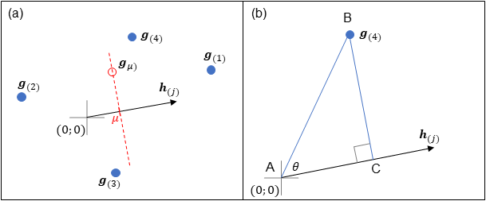

Figure 1: Calibration of biplot axes.

Since $\mathbf{p}$ is along $\mathbf{h}_{(j)}$ we can write $\mathbf{p} = c\mathbf{h}_{(j)}$ and all points on the prediction line $\mu = \mathbf{g}'_{\mu}\mathbf{h}_{(j)}$ project on the same point $c_{\mu}\mathbf{h}_{(j)}$. We solve for $c_{\mu}$ from
$$\mu = \mathbf{g}'_{\mu}\mathbf{h}_{(j)}=\| \mathbf{p} \| \|
\mathbf{h}_{(j)} \| =
\| c_{\mu}\mathbf{h}_{(j)} \| \| \mathbf{h}_{(j)} \|$$

$$c_{\mu} = \frac{\mu}{\mathbf{h}_{(j)}'\mathbf{h}_{(j)}}.$$
If we select ‘nice’ scale markers $\tau_{1}, \tau_{2}, \cdots \tau_{k}$ for variable $j$, then $\tau_{h}-\bar{x}_j = \mu_{h}$ and positions of these scale markers on $\mathbf{h}_{(j)}$ are given by $p_{\mu_{1}}, p_{\mu_{2}}, \cdots p_{\mu_{k}}$ with
$$p_{\mu_h} = c_{\mu_h}\mathbf{h}_{(j)}
= \frac{\mu_h}{\mathbf{h}_{(j)}'\mathbf{h}_{(j)}}\mathbf{h}_{(j)}
\tag{2}$$
To obtain a PCA biplot of the $48\times 4$ rock data in `R` we call

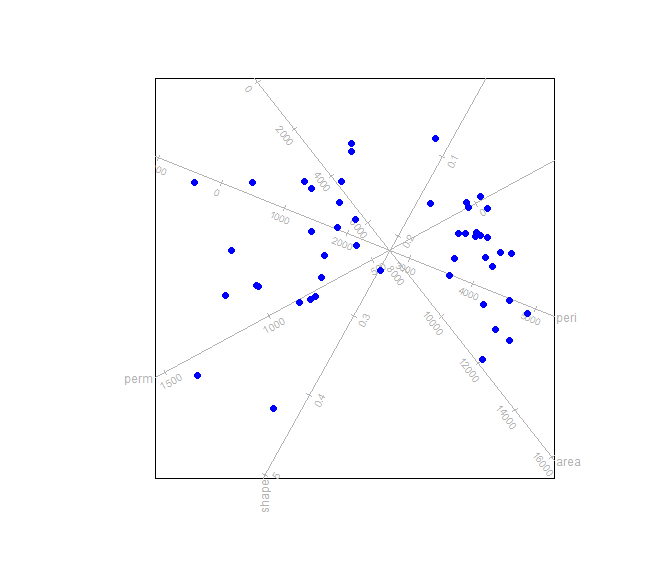

```r
biplot(rock, scale = TRUE) |> PCA() |> plot()
```

# 2 The function `biplot()`

The function `biplot()` takes a data set (usually) and outputs an object of class `biplot`.

```r
state.data <- data.frame (state.region, state.x77)
biplot(state.data)
```

```
#> Object of class biplot, based on 50 samples and 9 variables.
#> 8 numeric variables.
#> 1 categorical variable.
```

Apart from specifying a data set, we can specify a single variable for classification purposes.

```r
biplot(state.x77, classes=state.region)
```

```
#> Object of class biplot, based on 50 samples and 8 variables.
#> 8 numeric variables.
#> 4 classes: Northeast South North Central West
```

If we want to use the variable `state.region` for formatting, say colour coding the samples according to region, we instead specify `grouping.aes` to indicate it pertains to the aesthetics, rather than data structure. We can include or exclude the aestethics variable from the data set.

```r
biplot(state.x77, group.aes=state.region)
```

```
#> Object of class biplot, based on 50 samples and 8 variables.
#> 8 numeric variables.
```

Next, we look at centring and scaling of the numeric data matrix. As we saw in section 1 above, PCA is computed from the centred data matrix. For most methods, centring is either required or has no effect on the methodology, therefore the default is `center = TRUE`. Since centring is usually assumed, you will get a warning message, should you explicitly choose to set `center = FALSE`. The default for `scaled` is `FALSE`, but often when variables are in different units of measurement, it is advisable to divide each variable by its standard deviation which is accomplished by setting `scale = TRUE’.

```r
biplot(state.data)                 # centred, but no scaling
```

```
#> Object of class biplot, based on 50 samples and 9 variables.
#> 8 numeric variables.
#> 1 categorical variable.
```

```r
biplot(state.data, scale = TRUE)   # centered and scaled
```

```
#> Object of class biplot, based on 50 samples and 9 variables.
#> 8 numeric variables.
#> 1 categorical variable.
```

```r
biplot(state.data, center = FALSE) # no centring (usually not recommended) or scaling
```

```
#> Object of class biplot, based on 50 samples and 9 variables.
#> 8 numeric variables.
#> 1 categorical variable.
```

The final optional argument to the function is specifying a title for your plot. We notice in the output above, that centring and / or scaling has no effect on the `print method`. It does however have an effect on the components of the object of class `biplot` in the output.

```r
out <- biplot(state.data)                 # centred, but no scaling
out$center
```

```
#> [1] TRUE
```

```r
out$scaled
```

```
#> [1] FALSE
```

```r
out$means
```

```
#> Population     Income Illiteracy   Life.Exp     Murder    HS.Grad      Frost
#>  4246.4200  4435.8000     1.1700    70.8786     7.3780    53.1080   104.4600
#>       Area
#> 70735.8800
```

```r
out$sd
```

```
#> [1] 1 1 1 1 1 1 1 1
```

```r
out <- biplot(state.data, scale = TRUE)   # centered and scaled
out$center
```

```
#> [1] TRUE
```

```r
out$scaled
```

```
#> [1] TRUE
```

```r
out$means
```

```
#> Population     Income Illiteracy   Life.Exp     Murder    HS.Grad      Frost
#>  4246.4200  4435.8000     1.1700    70.8786     7.3780    53.1080   104.4600
#>       Area
#> 70735.8800
```

```r
out$sd
```

```
#>   Population       Income   Illiteracy     Life.Exp       Murder      HS.Grad
#> 4.464491e+03 6.144699e+02 6.095331e-01 1.342394e+00 3.691540e+00 8.076998e+00
#>        Frost         Area
#> 5.198085e+01 8.532730e+04
```

```r
out <- biplot(state.data, center = FALSE) # no centring (usually not recommended) or scaling
out$center
```

```
#> [1] FALSE
```

```r
out$scaled
```

```
#> [1] FALSE
```

```r
out$means
```

```
#> [1] 0 0 0 0 0 0 0 0
```

```r
out$sd
```

```
#> [1] 1 1 1 1 1 1 1 1
```

Note that the components `means` and `sd` only contain the sample means and sample sds when either/or `center` and `scaled` is `TRUE`. For values of `FALSE`, these components contain zeros for the `means` and/or ones for the `sd` to ensure back transformation will not have any affect.

## 2.1 Using `biplot()` with `princomp()` or `prcomp()`

Should the user wish to construct a PCA biplot after performing principal component analysis via the built in functions in the `stats` package, the output from either of these functions can be piped into the biplot function, where the piping implies that the argument `data` now takes the value of an object of class `prcomp` or `princomp`.

```r
princomp(state.x77) |> biplot()
```

```
#> Object of class biplot, based on 50 samples and 8 variables.
#> 8 numeric variables.
```

```r
out <- prcomp(state.x77, scale.=TRUE) |> biplot()
rbind (head(out$raw.X,3),tail(out$raw.X,3))
```

```
#>               Population Income Illiteracy Life Exp Murder HS Grad Frost   Area
#> Alabama             3615   3624        2.1    69.05   15.1    41.3    20  50708
#> Alaska               365   6315        1.5    69.31   11.3    66.7   152 566432
#> Arizona             2212   4530        1.8    70.55    7.8    58.1    15 113417
#> West Virginia       1799   3617        1.4    69.48    6.7    41.6   100  24070
#> Wisconsin           4589   4468        0.7    72.48    3.0    54.5   149  54464
#> Wyoming              376   4566        0.6    70.29    6.9    62.9   173  97203
```

```r
rbind (head(out$X,3),tail(out$X,3))
```

```
#>                Population      Income Illiteracy   Life Exp     Murder
#> Alabama       -0.14143156 -1.32113867   1.525758 -1.3621937  2.0918101
#> Alaska        -0.86939802  3.05824562   0.541398 -1.1685098  1.0624293
#> Arizona       -0.45568908  0.15330286   1.033578 -0.2447866  0.1143154
#> West Virginia -0.54819682 -1.33253061   0.377338 -1.0418703 -0.1836632
#> Wisconsin      0.07673438  0.05240289  -0.771082  1.1929438 -1.1859550
#> Wyoming       -0.86693413  0.21188994  -0.935142 -0.4384705 -0.1294853
#>                  HS Grad       Frost       Area
#> Alabama       -1.4619293 -1.62482920 -0.2347183
#> Alaska         1.6828035  0.91456761  5.8093497
#> Arizona        0.6180514 -1.72101848  0.5002047
#> West Virginia -1.4247868 -0.08580083 -0.5469045
#> Wisconsin      0.1723413  0.85685405 -0.1906996
#> Wyoming        1.2123316  1.31856256  0.3101835
```

```r
out$center
```

```
#> [1] TRUE
```

```r
out$scaled
```

```
#> [1] TRUE
```

```r
out$means
```

```
#> Population     Income Illiteracy   Life Exp     Murder    HS Grad      Frost
#>  4246.4200  4435.8000     1.1700    70.8786     7.3780    53.1080   104.4600
#>       Area
#> 70735.8800
```

```r
out$sd
```

```
#>   Population       Income   Illiteracy     Life Exp       Murder      HS Grad
#> 4.464491e+03 6.144699e+02 6.095331e-01 1.342394e+00 3.691540e+00 8.076998e+00
#>        Frost         Area
#> 5.198085e+01 8.532730e+04
```

# 3 The functions `PCA()`, `plot()` and `legend.type()`

The first argument to the function `PCA()` is an object of class `biplot`, i.e. the output of the `biplot()` function. By default we construct a 2D biplot (argument `dim.biplot = 2`) of the first two principal components (argument `e.vects = 1:2`). The `group.aes` argument, if not specified in the function `biplot()`, allows a grouping argument for the sample aesthetics. A PCA biplot of the `state.x77` data with colouring according to `state.region` is obtained as follows:

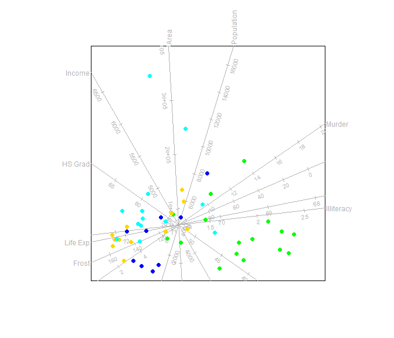

```r
biplot(state.x77, scaled = TRUE) |>
  PCA(group.aes = state.region) |> plot()
```

The output of `PCA()` is an object of class `PCA` which inherits from the class `biplot`. Four additional components are present in the `PCA` object. The matrix `Z` contains the coordinates of the sample points, while the matrix `Vr` contains the “coordinates” for the variables. In the notation of equation (1), Z=$\mathbf{G}:n \times 2$ and Vr=$\mathbf{H}:p \times 2$. The component `Xhat` is the matrix $\hat{\mathbf{X}}$ on the left hand side of equation (1). The final component `ax.one.unit` contains as rows the expression in equation (2) with $\mu_h=1$, in other words, one unit in the positive direction of the biplot axis.

By piping the `PCA` class object (inheriting from class `biplot`) to the generic `plot()` function, the `plot.biplot()` function constructs the biplot on the graphical device. To add a legend to the biplot, we call

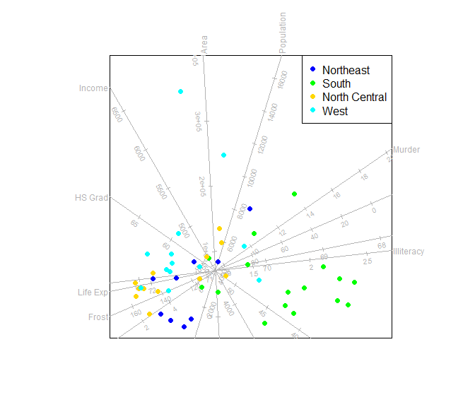

```r
biplot(state.x77, scaled = TRUE) |>
  PCA(group.aes = state.region) |>
  legend.type(samples = TRUE) |> plot()
```

It was mentioned in section 1 that the default choice $\mathbf{G}=\mathbf{UDJ}_2$ and $\mathbf{H}=\mathbf{VJ}_2$ provides an exact representation of the distances between the rows of $\mathbf{\hat{X}}$ which is an optimal approximation in the least squares sense of the distances between the rows of $\mathbf{X}$ (samples). Alternatively, the correlations between the variables (columns of $\mathbf{X}$) can be optimally approximated by the cosines of the angles between the axes, leaving the approximation of the distances between the samples to be suboptimal. In this case $\mathbf{G}=\mathbf{UJ}_2$ and $\mathbf{H}=\mathbf{VDJ}_2$ and this biplot is obtained by setting the argument `correlation.biplot = TRUE`.

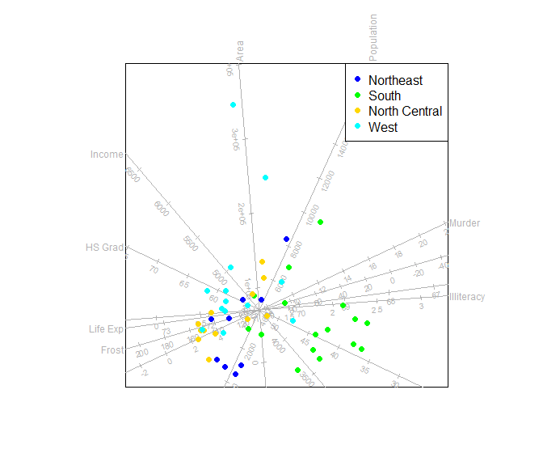

```r
biplot(state.x77, scaled = TRUE) |>
  PCA(group.aes = state.region, correlation.biplot = TRUE) |>
  legend.type(samples = TRUE) |> plot()
```

# 4 The function `samples()`

This function controls the aesthetics of the sample points in the biplot. The function accepts as first argument an object of class `biplot` where the aesthetics should be applied. Let us first construct a PCA biplot of the `state.x77` data with samples coloured according to `state.division`.

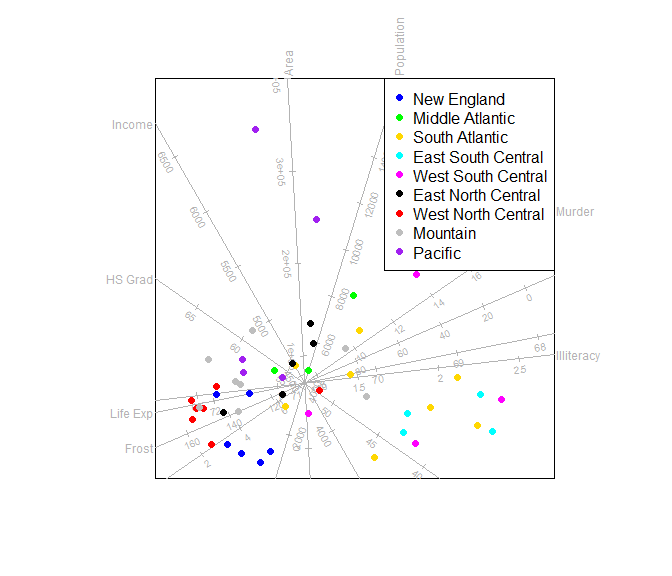

```r
biplot(state.x77, scaled = TRUE) |>
  PCA(group.aes = state.division) |>
  legend.type(samples = TRUE) |> plot()
```

Since the legend interferes with the sample points, we choose to place the legend on a new page, by setting `new = TRUE` in the `legend.type` function. Furthermore, we wish to select colours, other than the defaults, for the divisions. We can also change the opacity of the sample colours with the argument `opacity` that has default 1.

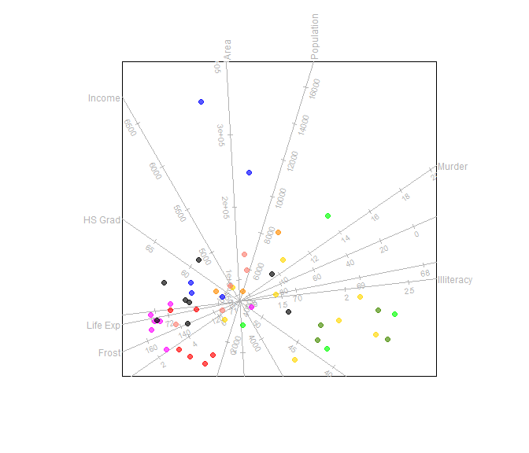

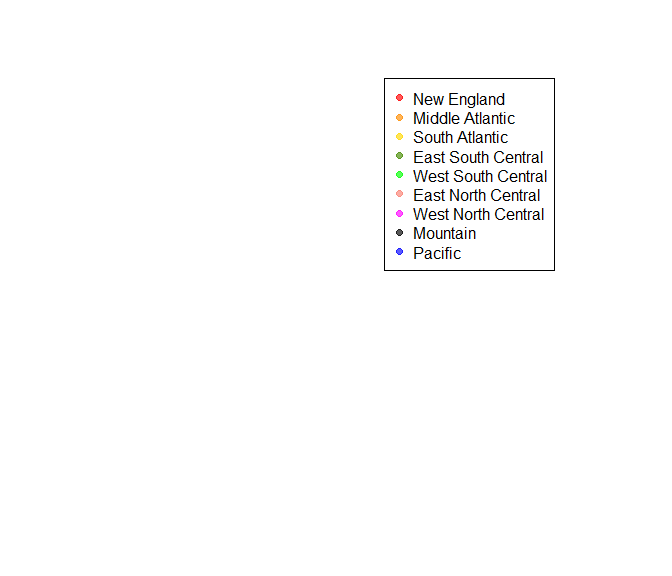

```r
biplot(state.x77, scaled = TRUE) |>
  PCA(group.aes = state.division) |>
  samples (col = c("red", "darkorange", "gold", "chartreuse4",
                   "green", "salmon", "magenta", "#000000", "blue"),opacity = 0.65,pch=19) |>
  legend.type(samples = TRUE, new = TRUE) |> plot()
```

Furthermore we want to use a different plotting character for the central regions.

```r
levels (state.division)
```

```
#> [1] "New England"        "Middle Atlantic"    "South Atlantic"
#> [4] "East South Central" "West South Central" "East North Central"
#> [7] "West North Central" "Mountain"           "Pacific"
```

We want to use `pch = 15` for the first three and final two divisions and `pch = 1` for the remaining four divisions.

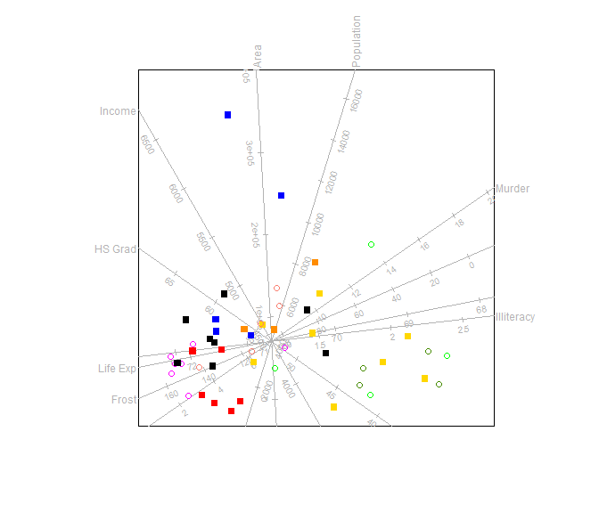

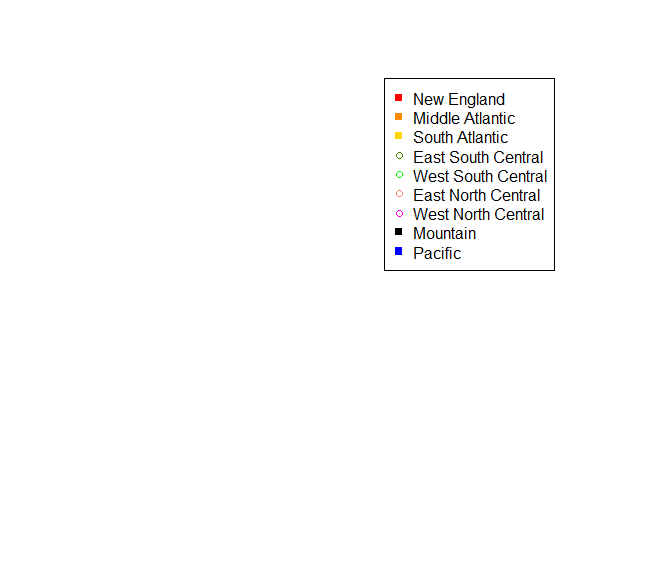

```r
biplot(state.x77, scaled = TRUE) |>
  PCA(group.aes = state.division) |>
  samples (col = c("red", "darkorange", "gold", "chartreuse4",
                   "green", "salmon", "magenta", "black", "blue"),
           pch = c(15, 15, 15, 1, 1, 1, 1, 15, 15)) |>
  legend.type(samples = TRUE, new = TRUE) |> plot()
```

To increase the size of the plotting characters of the eastern states, we add the following:

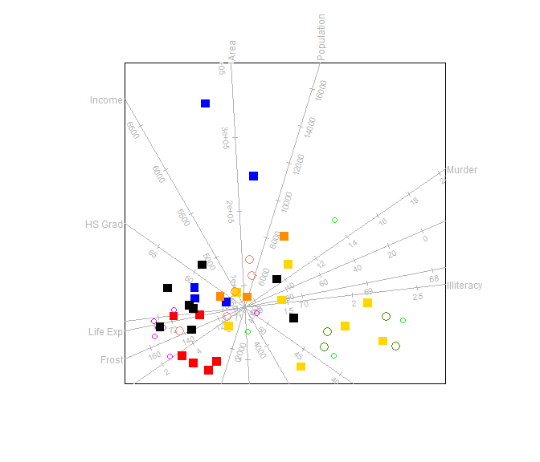

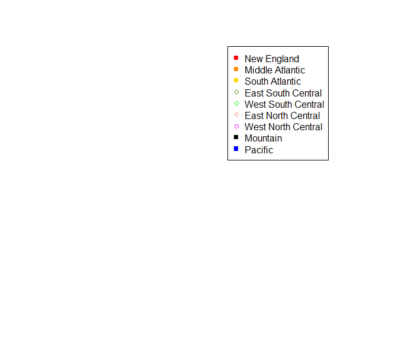

```r
biplot(state.x77, scaled = TRUE) |>
  PCA(group.aes = state.division) |>
  samples (col = c("red", "darkorange", "gold", "chartreuse4",
                   "green", "salmon", "magenta", "black", "blue"),
           pch = c(15, 15, 15, 1, 1, 1, 1, 15, 15),
           cex = c(rep(1.5,4), c(1,1.5,1,1.5))) |>
  legend.type(samples = TRUE, new = TRUE)  |> plot()
```

If we choose to only show the samples for the central states, the argument `which` is used either indicating the number(s) in the sequence of levels (`which = 4:7`), or as shown below, the levels themselves:

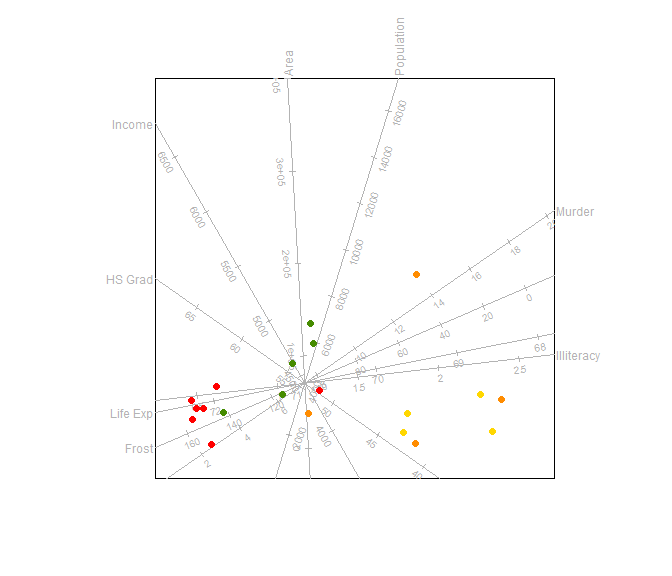

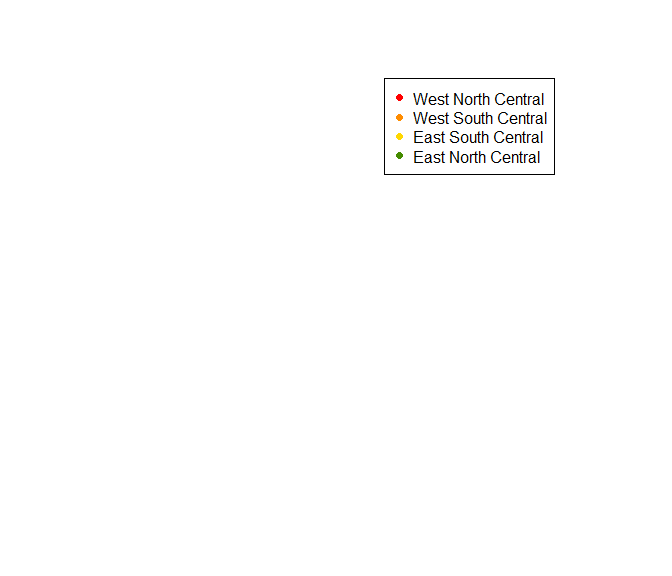

```r
biplot(state.x77, scaled = TRUE) |>
  PCA(group.aes = state.division) |>
  samples (col = c("red", "darkorange", "gold", "chartreuse4",
                   "green", "salmon", "magenta", "black", "blue"),
           which = c("West North Central", "West South Central", "East South Central",
                     "East North Central")) |>
  legend.type(samples = TRUE, new = TRUE)  |> plot()
```

Note that since four regions are selected, the colour (and other aesthetics) is applied to these regions in the order they are specified in `which`. To add the sample names, the `label` argument is set to `TRUE`. For large sample sizes, this is not recommended, as overplotting will render the plot unusable. The size of the labels is controlled with `label.cex` which can be specified either as a single value (for all samples) or a vector indicating size values for each individual sample. The colour of the labels defaults to the colour(s) of the samples. However, individual label colours can be spesified with `label.col`, similar to `label.cex` as either a single value of a vector of length equal to the number of samples.

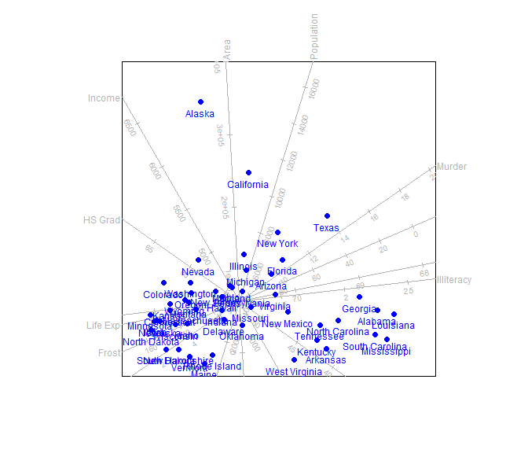

```r
biplot(state.x77, scaled = TRUE) |> PCA() |>
  samples (label = TRUE) |> plot()
```

We can use the arguments `label.cex`, `label.side` and `label.offset` to make the plot more legible with a little effort.

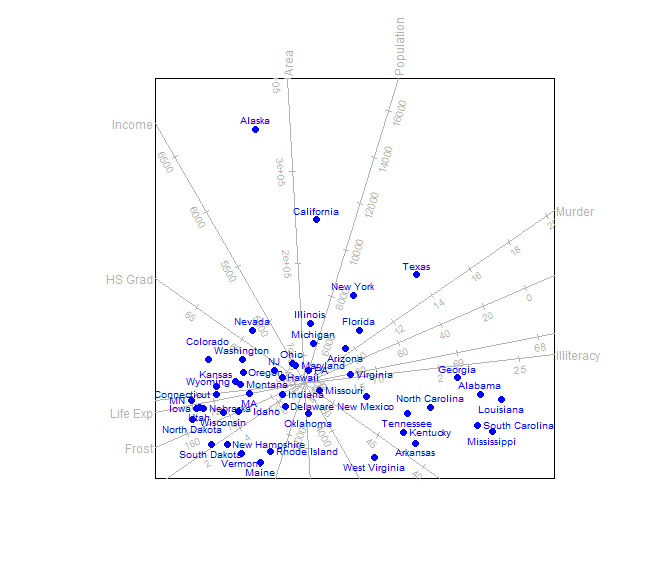

```r
rownames(state.x77)[match(c("Pennsylvania", "New Jersey", "Massachusetts",
                            "Minnesota"), rownames(state.x77))] <- c("PA", "NJ", "MA", "MN")
above <- match(c("Alaska", "California", "Texas", "New York", "Nevada", "Georgia", "Alabama",
                 "North Carolina", "Colorado", "Washington", "Illinois", "Michigan", "Arizon",
                 "Florida", "Ohio", "NJ", "Kansas"), rownames(state.x77))
right.side <- match(c("South Carolina", "Kentucky", "Rhode Island", "New Hampshire", "Virginia",
                      "Missouri", "Delaware", "Hawaii", "Oregon", "PA", "Nebraska", "Montana",
                      "Maryland", "Indiana", "Idaho"), rownames(state.x77))
left.side <- match(c("Wyoming", "Iowa", "MN", "Connecticut"), rownames(state.x77))
label.offset <- rep(0.3, nrow(state.x77))
label.offset[match(c("Colorado", "Kansas", "Idaho"), rownames(state.x77))] <- c(0.8, 0.5, 0.8)
label.side <- rep("bottom", nrow(state.x77))
label.side[above] <- "top"
label.side[right.side] <- "right"
label.side[left.side] <- "left"
biplot (state.x77, scaled=TRUE) |> PCA() |>
  samples (label=TRUE, label.cex=0.6, label.side=label.side, label.offset=label.offset) |>
  plot()
```

We can also make use of the functionality of the `ggrepel` package to place the labels.

[output not shown]

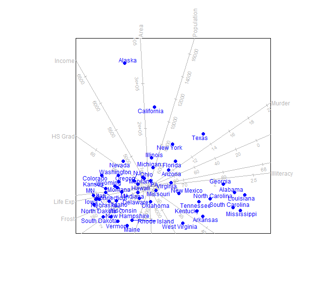

```r
biplot(state.x77, scaled = TRUE) |> PCA() |>
  samples (label = "ggrepel") |> plot()
```

Additionally, the user can add customised label names to the samples in the biplot. To do this, `label` must be set to `TRUE` (or `"ggrepel"`) and `label.name` is set to be a vector of size `n` specifying the label names of the samples. In this case, the label name is set to the first three characters of the state name (row names of the data).

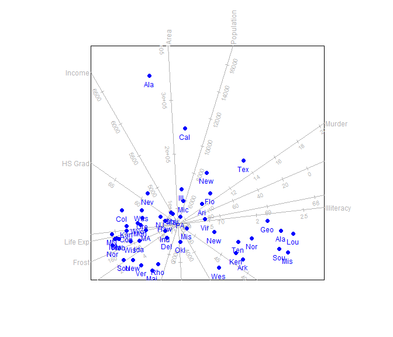

```r
biplot(state.x77, scaled = TRUE) |> PCA() |>
  samples (label = "TRUE",label.name=strtrim(row.names(state.x77),3)) |> plot()
```

If the data plotted in the biplot is a multivariate time series, it can make sense to connect the data points in order. Let us consider the four quarters of the `UKgas` data set as four variables and we represent the years as sample points in a PCA biplot.

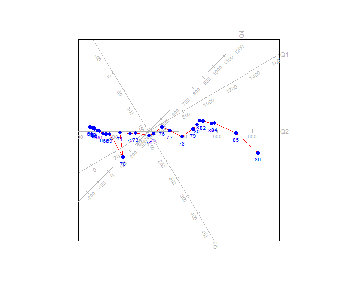

```r
gas.data <- matrix (UKgas, ncol=4, byrow=T)
colnames(gas.data) <- paste("Q", 1:4, sep="")
rownames(gas.data) <- 60:86
even.labels <- rep(c(TRUE, FALSE), 14)
biplot(gas.data, scaled = TRUE) |> PCA() |>
  samples (connected = TRUE, connect.col="red", label = even.labels, label.cex=0.6) |>
  plot()
```

# 5 The function `means()`

The function `means()` allow changing the aesthetics for group means specified by group.aes, when the argument `show.class.means = TRUE` in the call to the function `PCA()`. The functionality of `means()` mirrors that of `samples()` and is discussed in detail in the vignette *Class separation* where class means are more prominent than in PCA biplots.

# 6 The function `axes()`

Similar to the `samples()` function, this function allows for changing the aestethics of the biplot axes. The first argument to `axes()` is an object of class `biplot`. The `X.names` argument is typically not specified by the user, but is required for the function to allow specifying which axes to display in the `which` argument, by either speficying the column numbers  
or the column names. The arguments `col`, `lwd` and `lty` pertains to the axes themselves and can be specified either as a scaler value (to be recycled) or a vector with length equal to that of `which`.

To construct a PCA biplot of the rock data, displaying only the axes for peri and shape with different colours for the two axes, different line widths and line type 2, we need to following code:

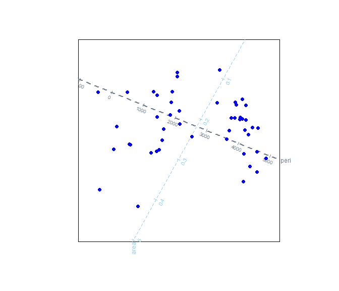

```r
biplot(rock, scaled = TRUE) |> PCA() |>
                               axes(which = c("shape","peri"),
                                    col=c("lightskyblue","slategrey"),
                                    lwd = c(1,2), lty=2) |>
                               plot()
```

The following four arguments deal with the axis labels. The argument `label.dir` is based on the graphics parameter `las` and allows for labels to be either orthogonal to the axis direction (`Orthog`), horisontal (`Hor`) or parallel to the plot `Paral`. The argument `label.line` fulfills the role of the `line` argument in `mtext()` to determine on which margin line (how far from the plot) the label is placed while `label.col` and `label.cex` is self-explanatory and defaults to the axis colour and size 0.75. Note in for the illustration the in the code below the colour vector has only three components, so that recycling is applied.

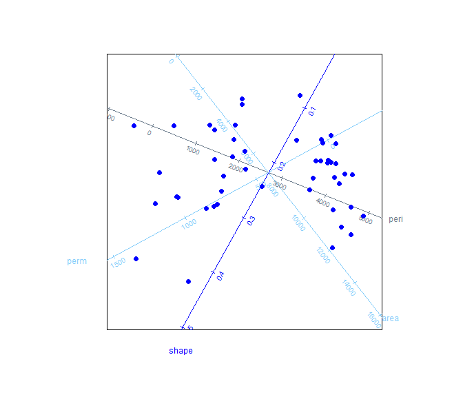

```r
biplot(rock, scaled = TRUE) |> PCA() |>
                               axes(col=c("lightskyblue","slategrey","blue"),
                                    label.dir="Hor", label.line=c(0,0.5,1,1.5)) |>
                               plot()
```

The function `pretty()` finds ‘nice’ tick marks where the value specified in the argument `ticks` determine the *desired* number of tick marks, although the observed number could be different. The other `tick.*` arguments are similar to their naming counterparts in `par()` or `text()`. Since the tick labels are important to follow the direction of increasing values of the axes, setting `tick.label = FALSE` does not remove the tick marks completely, but limits the labels to the smallest and largest value visible in the plot. If the user would like to specify alternative names for the axes, this can be done in the argument `ax.names`.

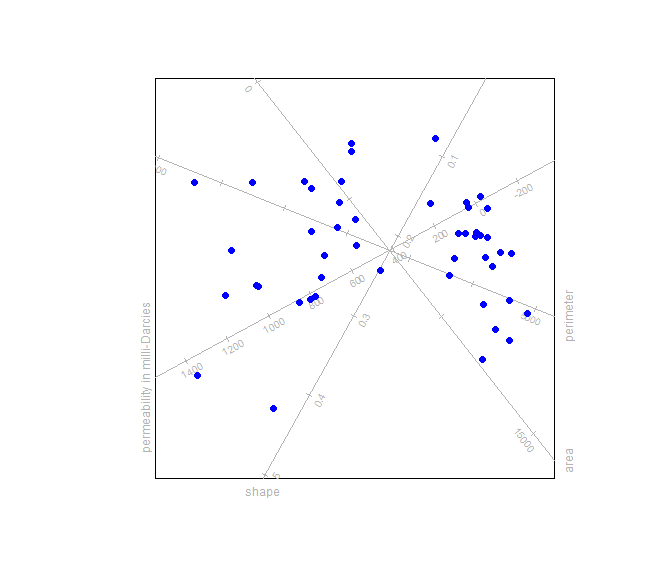

```r
biplot(rock, scaled = TRUE) |> PCA() |>
                               axes(label.dir="Paral",
                                    ticks = c(3, 5, 5, 10), tick.label=c(F, F, T, T),
                                    ax.names = c("area", "perimeter", "shape",
                                                 "permeability in milli-Darcies")) |>
                               plot()
```

# 7 The functions `fit.measures()` and `summary()`

The `print` method provides a short summary of the biplot object.

```r
  obj <- biplot(airquality)
  obj
```

```
#> Object of class biplot, based on 111 samples and 6 variables.
#> 6 numeric variables.
#>
#> The following 42 sample-rows where removed due to missing values
#>  5 6 10 11 25 26 27 32 33 34 35 36 37 39 42 43 45 46 52 53 54 55 56 57 58 59 60 61 65 72 75 83 84 96 97 98 102 103 107 115 119 150
```

The output from `summary()` will be very similar.

```r
  summary(obj)
```

```
#> Object of class biplot, based on 111 samples and 6 variables.
#> 6 numeric variables.
#>
#> The following 42 sample-rows were removed due to missing values
#>  5 6 10 11 25 26 27 32 33 34 35 36 37 39 42 43 45 46 52 53 54 55 56 57 58 59 60 61 65 72 75 83 84 96 97 98 102 103 107 115 119 150
```

Additional information about the biplot object is added by the `fit.measures()` function.

## 7.1 Quality of approximation

We start with the identity

$$\mathbf{X} = \mathbf{\hat{X}} + \mathbf{X-\hat{X}}$$
which decomposes $\mathbf{X}$ into a fitted part

$$\mathbf{\hat{X}} = \mathbf{UJDJV'} =
\mathbf{UDJ}_2(\mathbf{VJ}_2)' =
\mathbf{UDV'VJ}_2(\mathbf{VJ}_2)' = \mathbf{XVJV'}$$

and the residual part $\mathbf{X-\hat{X}}$. The lack of fit is quantified by the quantity we are minimising

$$\| \hat{\mathbf{X}}-\mathbf{X} \|^2$$
where we have the orthogonal decomposition

$$\|\mathbf{X}\|^2 = \|\hat{\mathbf{X}}\|^2 +
\|\hat{\mathbf{X}}-\mathbf{X} \|^2.$$
The overall quality of fit is therefore defined as

$$quality =\frac{d_1^2+d_2^2}{d_1^2+\dots+d_p^2}100\%.$$

## 7.2 Adequacy of representation of the variables

Researchers who construct the PCA biplot representing the columns with arrows (vectors) often fit the biplot with a unit circle. The rationale being that perfect representation of a variable will have unit length and the length of each arrow vs the distance to the unit circle represent the adequacy with which the variable is represented.

By fitting the biplot with calibrated axes, it is much easier to read off values for the variables, but the adequacy values can still be computed from

$$\frac{diag(\mathbf{V}_r\mathbf{V}_r')}{diag(\mathbf{VV}')}=
diag(\mathbf{V}_r\mathbf{V}_r')$$

due to the orthogonality of the matrix $\mathbf{V}:p \times p$.

## 7.3 Predictivities

The predictivity provides a measure of how well the original values are recovered from the biplot. An element that is well represented will have a predictivity close to one, indicating that the sample or variable values from prediction is close to the observed values. If an element is poorly represented, the predicted values will be very different from the original values and the predictivity value will be close to zero.

### 7.3.1 Axis predictivity

The predictivity for each of the $p$ variables is computed as the elementwise ratios

$$axis \: predictivity =
\frac{diag(\mathbf{\hat{X}'\hat{X}})}{diag(\mathbf{X'X})}$$

### 7.3.2 Sample predictivity

The predictivity for each of the $n$ samples is computed as the elementwise ratios

$$sample \: predictivity =
\frac{diag(\mathbf{\hat{X}\hat{X}'})}{diag(\mathbf{XX'})}$$
By calling the function `fit.measures()` these quantities are computed for the specific biplot object. The values are displayed with the `summary()` function.

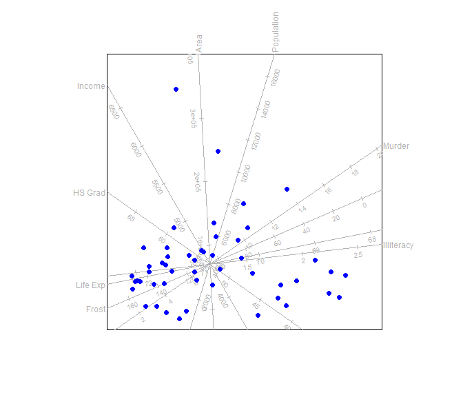

```r
obj <- biplot(state.x77, scale = TRUE) |> PCA() |>
  fit.measures() |> plot()
```

```r
summary (obj)
```

```
#> Object of class biplot, based on 50 samples and 8 variables.
#> 8 numeric variables.
#>
#> Quality of fit in 2 dimension(s) = 65.4%
#> Adequacy of variables in 2 dimension(s):
#> Population     Income Illiteracy   Life Exp     Murder    HS Grad      Frost
#>  0.1848016  0.3586383  0.2215201  0.1760908  0.2915819  0.2696184  0.1513317
#>       Area
#>  0.3464170
#> Axis predictivity in 2 dimension(s):
#> Population     Income Illiteracy   Life Exp     Murder    HS Grad      Frost
#>  0.3330216  0.7609185  0.7917091  0.6206172  0.8640485  0.7947530  0.4982299
#>       Area
#>  0.5675169
#> Sample predictivity in 2 dimension(s):
#>        Alabama         Alaska        Arizona       Arkansas     California
#>     0.95126856     0.61373919     0.26327256     0.86308539     0.57062754
#>       Colorado    Connecticut       Delaware        Florida        Georgia
#>     0.83358779     0.59003002     0.18284712     0.49725356     0.94461052
#>         Hawaii          Idaho       Illinois        Indiana           Iowa
#>     0.01984127     0.70337480     0.33405270     0.30082350     0.96367113
#>         Kansas       Kentucky      Louisiana          Maine       Maryland
#>     0.86554676     0.87758262     0.93717163     0.66553856     0.06362508
#>             MA       Michigan             MN    Mississippi       Missouri
#>     0.47386267     0.26050188     0.89207404     0.93073099     0.11321791
#>        Montana       Nebraska         Nevada  New Hampshire             NJ
#>     0.44603781     0.93570441     0.22393876     0.87499561     0.15979033
#>     New Mexico       New York North Carolina   North Dakota           Ohio
#>     0.29304145     0.40609063     0.93004841     0.69011551     0.08810179
#>       Oklahoma         Oregon             PA   Rhode Island South Carolina
#>     0.37520943     0.36273523     0.02176080     0.58625617     0.93187284
#>   South Dakota      Tennessee          Texas           Utah        Vermont
#>     0.83804787     0.96006357     0.73748654     0.66209083     0.80365601
#>       Virginia     Washington  West Virginia      Wisconsin        Wyoming
#>     0.58564755     0.33877314     0.85231725     0.82519206     0.42499724
```

If is not necessary to call the `plot()` function to obtain the fit measures, but one of the biplot methods, such as `PCA()` is required, since the measures differ depending on which type of biplot is constructed. To suppress the output of some fit measures, for instance if the interest is in the axis predictivity and there are many samples which result in a very long output, these can be set in the call to `summary()`. By default all measures are set to `TRUE`.

```r
obj <- biplot(state.x77, scale = TRUE) |> PCA() |>
  fit.measures()
summary (obj, adequacy = FALSE, sample.predictivity = FALSE)
```

```
#> Object of class biplot, based on 50 samples and 8 variables.
#> 8 numeric variables.
#>
#> Quality of fit in 2 dimension(s) = 65.4%
#> Axis predictivity in 2 dimension(s):
#> Population     Income Illiteracy   Life Exp     Murder    HS Grad      Frost
#>  0.3330216  0.7609185  0.7917091  0.6206172  0.8640485  0.7947530  0.4982299
#>       Area
#>  0.5675169
```

The axis predictivities and sample predictivities can be represented in the biplot in two ways: setting either `axis.predictivity` and / or `sample.predictivity` to `TRUE`, applies shading for axes and shrinking for samples according to the predictivity values.

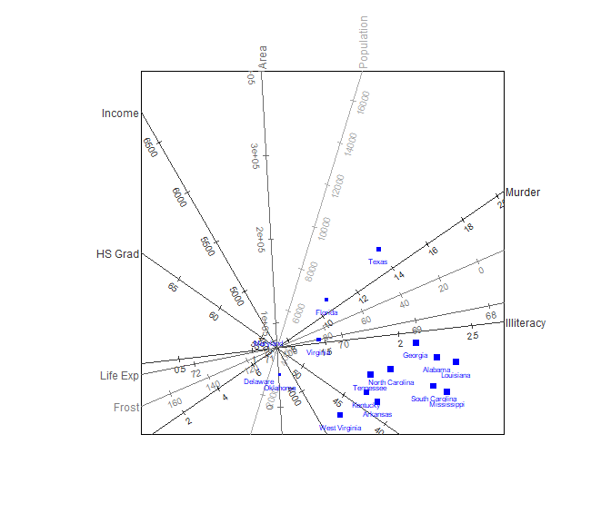

```r
biplot(state.x77, scale = TRUE) |> PCA(group.aes = state.region) |>
  samples (which = "South", pch = 15, label = T, label.cex=0.5) |>
  axes (col = "black") |>
  fit.measures() |> plot (sample.predictivity = TRUE,
                          axis.predictivity = TRUE)
```

Comparing the plot with the `summary` output it is clear that the variables Population and Frost are not very well represented and it can be expected that predictions on these variables will be less accurate. Furthermore, the samples located close to the origin are not as well represented as those located towards the bottom right. This is typically the case where samples nearly orthogonal to the PCA plane are projected close to the origin and due to their orthogonality, very poorly represented.

### 7.3.3 Axes represented as vectors

If the user wishes to view the variables as arrows on the biplot to give information on the adequacy of the variables, this can be done with the `axes()` function, by setting `vectors = TRUE` and `unit.circle = TRUE`. The adequacy value is given by squared length of the arrow.

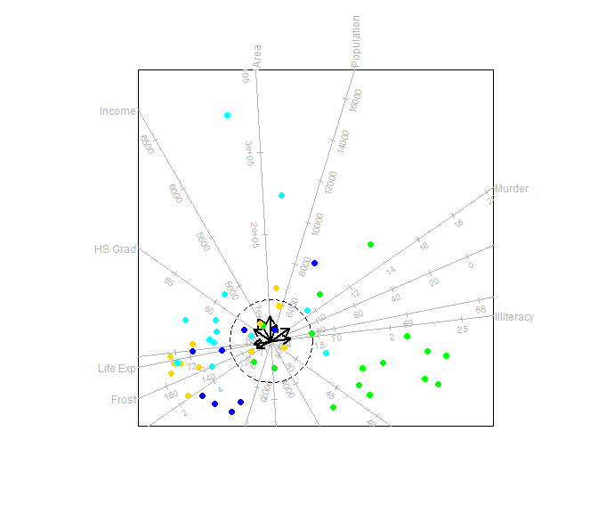

```r
biplot(state.x77, scale = TRUE) |> PCA(group.aes = state.region) |>
  axes (vectors = TRUE,unit.circle = TRUE) |>
  fit.measures() |> plot ()
```

# References

Eckart, C., and G. Young. 1936. “The Approximation of One Matrix by Another of Lower Rank.” *Psychometrika*, 211–18.

Gabriel, K. R. 1971. “The Biplot Graphic Display of Matrices with Application to Principal Component Analysis.” *Biometrika*, 453–67.